# Lab 8

Author

Shubhu Shahade

Published

October 18, 2023

Remember, you must submit *both* your .Rmd and the compiled .html in order to receive full credit! In addition, to receive full credit, your code output and plots must be correctly formatted.

### Collaborators

```r
# LOAD ANY RELEVANT PACKAGES HERE
library(ggplot2)
```

## A. Writing a simulation.

Suppose $X_i\sim \mathrm{N}(0, 1)$ for $1\leq i\leq n$, for some $n$.

1. For $n=10, 20, 40, 80, 160, 320, 640, 1280$, carry out a simulation to estimate $E(\mathrm{max}(X_1,\ldots, X_n))$. For each value of $n$, simulate 1000 values of $\mathrm{max}(X_1,\ldots, X_n)$ and compute their mean. Store these means in a vector.

```r
n_values <- c(10, 20, 40, 80, 160, 320, 640, 1280)
n_simulations <- 1000

means <- numeric(length(n_values))
set.seed(123)

# Perform simulations for each value of n
for (i in 1:length(n_values)) {
  n <- n_values[i]
  max_values <- replicate(n_simulations, max(rnorm(n)))
  means[i] <- mean(max_values)
}

cat("Estimated Means:\n")
```

```
Estimated Means:
```

```r
print(means)
```

```
[1] 1.542815 1.862051 2.156573 2.439066 2.702067 2.877130 3.119538 3.311966
```

2. Create a line graph with $n$ on the x-axis and your simulation-based estimates of $E(\mathrm{max}(X_1,\ldots, X_n))$ on the y-axis. Comment on your findings. Does there seem to be an upper limit of $E(\mathrm{max}(X_1,\ldots, X_n))$?

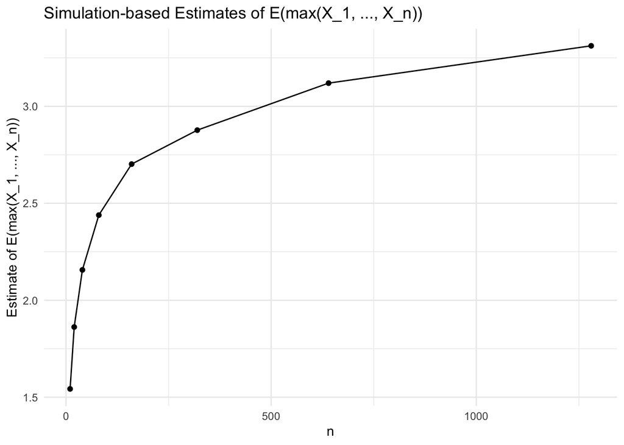

```r
data <- data.frame(n = n_values, estimate = means)

# Create the line graph
ggplot(data, aes(x = n, y = estimate)) +
  geom_line() +
  geom_point() +
  labs(x = "n", y = "Estimate of E(max(X_1, ..., X_n))") +
  ggtitle("Simulation-based Estimates of E(max(X_1, ..., X_n))") +
  theme_minimal()
```

## B. One-dimensional random walks

In this part, you will simulate a one-dimensional random walk. Suppose you are at the point $x$ at time $t$. At time $t+1$, the probability of moving forwards to $x+1$ is $p$ and the chance of moving backwards to $x-1$ is $1-p$. Assume that at time $t=1$, you are at $x_1=0$.

3. Write a function `random_walk()` that takes as input a numeric `n_steps` and a numeric $p$ and simulates `n_steps` steps of the one-dimensional random walk with forward probability $p$. You may have other input arguments if desired. The output should be a length vector of length `n_steps` starting with 0 where the $i$th entry represents the location of the random walker at time $t=i$. For example, `random_walk(5, .5)` may return the vector $(0, 1, 2, 1, 2)$.

```r
random_walk <- function(n_steps, p) {
  positions <- numeric(n_steps + 1)
  positions[1] <- 0

  # Simulate the random walk
  for (i in 1:n_steps) {
    # Generate a random number to decide whether to move forward or backward
    move <- ifelse(runif(1) < p, 1, -1)
    positions[i + 1] <- positions[i] + move
  }

  return(positions)
}
```

4. Use your function to generate a random walk of 500 steps with probability $.6$ and generate a line graph with $t=0,1,\ldots, 100$ on the x-axis and $x_0,\ldots, x_{100}$ on the y-axis.

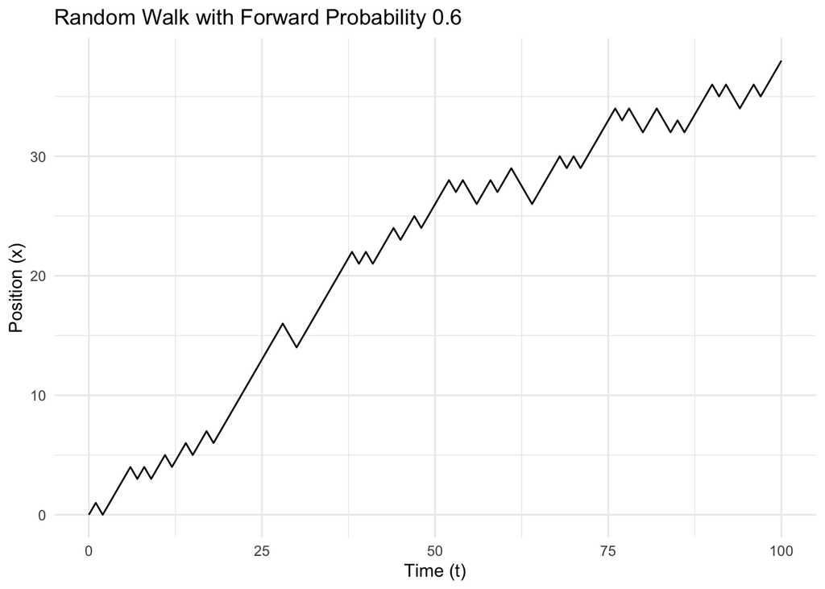

```r
n_steps <- 500
p <- 0.6
random_walk_data <- random_walk(n_steps, p)

t_values <- 0:100
x_values <- random_walk_data[1:101]

# Create a data frame for plotting
walk_data <- data.frame(t = t_values, x = x_values)

# Create the line graph
ggplot(walk_data, aes(x = t, y = x)) +
  geom_line() +
  labs(x = "Time (t)", y = "Position (x)") +
  ggtitle("Random Walk with Forward Probability 0.6") +
  theme_minimal()
```

5. Use your function to generate two more random walks of 500 steps with probability $.6$ and create a line graph with all three of your random walks, using different colors for each walk.

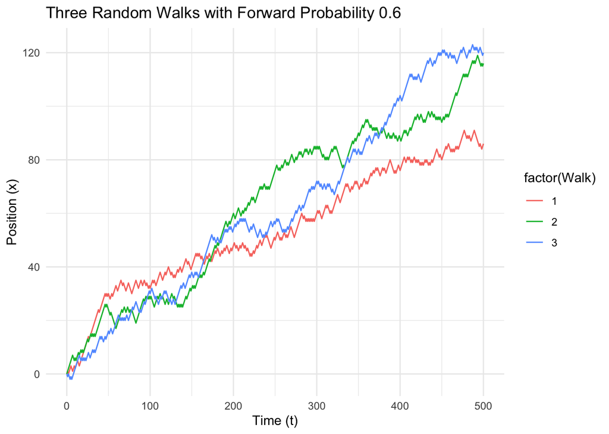

```r
random_walk1 <- random_walk(n_steps, p)
random_walk2 <- random_walk(n_steps, p)
random_walk3 <- random_walk(n_steps, p)

# Create a data frame for plotting
walk_data <- data.frame(
  t = rep(0:n_steps, 3),
  x = c(random_walk1, random_walk2, random_walk3),
  Walk = rep(1:3, each = n_steps + 1)
)

# Create the line graph
ggplot(walk_data, aes(x = t, y = x, color = factor(Walk))) +
  geom_line() +
  labs(x = "Time (t)", y = "Position (x)") +
  ggtitle("Three Random Walks with Forward Probability 0.6") +
  theme_minimal()
```